Let's put all of the information together.

```python
# region wise analysis imports
import folium
from folium.plugins import MarkerCluster

# sklearn imports
from sklearn.feature_extraction.text import CountVectorizer, TfidfTransformer
from sklearn.decomposition import LatentDirichletAllocation
from sklearn.cluster import AffinityPropagation
from sklearn.decomposition import LatentDirichletAllocation
from sklearn.decomposition import NMF

# topic analysis imports and word cloud imports
import pandas as pd
from nltk.tokenize import word_tokenize
from nltk.corpus import stopwords
from nltk.corpus import wordnet
from nltk.stem import WordNetLemmatizer
from sklearn.feature_extraction.text import CountVectorizer, TfidfVectorizer
from sklearn.decomposition import LatentDirichletAllocation
import gensim
import gensim.corpora as corpora
import re
import numpy as np
from pprint import pprint
import pyLDAvis
import pyLDAvis.gensim
import matplotlib.pyplot as plt
%matplotlib inline
import warnings
warnings.filterwarnings("ignore",category=DeprecationWarning)

from wordcloud import WordCloud

# sns plots

from collections import Counter
import seaborn as sns
import matplotlib.pyplot as plt
import pandas as pd

# network visualization

from itertools import combinations
import networkx as nx
from nxviz.plots import CircosPlot
```

# Region wise analysis

```python
# notebook 4_primary_analyses_country_wise
df_n = pd.read_csv('/home/mrinalmanu/Desktop/metagen_project/pre_cleaned_DF_2')

# geographical coods
coods = df_n.loc[:, ['code', 'latitude', 'longitude']]
coods = coods.drop_duplicates(subset=['code'], keep='first')
coods

# country wise stats
x_country = df_n.groupby(['code']).size().reset_index(name='country_count')
x_country = pd.merge(x_country, coods, left_on='code', right_on='code')
#x_country.head(5)
```

Continent wise summary

```python
# continent wise stats

# country info
iso_info = pd.read_csv('/home/mrinalmanu/Desktop/metagen_project/countries_2')

x_continent = pd.merge(x_country, iso_info, left_on='code', right_on='code')

del x_continent['timezones']
del x_continent['capital']

y_x = x_continent.groupby('continent', as_index=False)['country_count'].sum()

y_y = x_continent.groupby('continent', as_index=False)['latitude'].mean()

y_z = x_continent.groupby('continent', as_index=False)['longitude'].mean()
y_continent = pd.merge(pd.merge(y_x,y_y,on='continent'),y_z,on='continent')

# drop NAs

x_continent = x_continent[x_continent['latitude'].notna()]
x_continent = x_continent[x_continent['longitude'].notna()]

# normalise counts
x_continent["country_count_norm"] = x_continent["country_count"] / x_continent["country_count"].max()

# continent summary
y_continent
```

|  | continent | country_count | latitude | longitude |
| --- | --- | --- | --- | --- |
| 0 | Africa | 1115 | 4.678031 | 18.914494 |
| 1 | America | 95 | 18.220833 | -66.590149 |
| 2 | Asia | 6065 | 26.744679 | 77.302149 |
| 3 | Europe | 7800 | 48.850277 | 15.238116 |
| 4 | North America | 7544 | 20.620731 | -76.209697 |
| 5 | Oceania | 893 | -11.252902 | 160.714510 |
| 6 | South America | 588 | -16.035346 | -66.153357 |

World map to showing distributions of researchers and their contributions

```python
# Create a world map to show distributions of researchers and their contributions

#empty map
world_map= folium.Map(tiles="cartodbpositron")
marker_cluster = MarkerCluster().add_to(world_map)
#for each coordinate, create circlemarker of user percent
for i in range(len(x_continent)):
        lat = x_continent.iloc[i]['latitude']
        long = x_continent.iloc[i]['longitude']
        radius = float(x_continent.iloc[i]['country_count_norm'])*100# bubble map parameter
        popup_text = """continent : {}<br>
                    a) total contributions for the given topic : {}
                    b) percentage contribution : {} % <br>"""
        popup_text = popup_text.format(x_continent.iloc[i]['name'],
                                   x_continent.iloc[i]['country_count'],
                                       round(x_continent.iloc[i]['country_count_norm']*100, 2)
                                   )
        folium.CircleMarker(location = [lat, long], radius=radius, popup= popup_text, fill =True).add_to(marker_cluster)
#show the map
world_map
```

Make this Notebook Trusted to load map: File -> Trust Notebook

[interactive chart not shown]

Top 20 major contributors The country_count column represents number of researchers affiliated with a given country/ institute in a country.

```python
stats = x_continent
stats.sort_values("country_count_norm", inplace=True, ascending=False)
del stats['latitude']
del stats['longitude']
stats.head(n=20)
```

|  | code | country_count | continent | name | country_count_norm |
| --- | --- | --- | --- | --- | --- |
| 135 | US | 5393 | North America | United States | 1.000000 |
| 23 | CN | 2028 | Asia | People's Republic of China | 0.376043 |
| 20 | CA | 1572 | North America | Canada | 0.291489 |
| 28 | DE | 1272 | Europe | Germany | 0.235861 |
| 94 | NL | 768 | Europe | Kingdom of the Netherlands | 0.142407 |
| 36 | ES | 762 | Europe | Spain | 0.141294 |
| 7 | AU | 712 | Oceania | Australia | 0.132023 |
| 60 | IT | 706 | Europe | Italy | 0.130910 |
| 12 | BE | 581 | Europe | Belgium | 0.107732 |
| 63 | JP | 528 | Asia | Japan | 0.097905 |
| 40 | FR | 483 | Europe | France | 0.089561 |
| 56 | IN | 469 | Asia | India | 0.086965 |
| 55 | IL | 451 | Asia | Israel | 0.083627 |
| 131 | TW | 418 | Asia | Taiwan | 0.077508 |
| 78 | MA | 418 | Africa | Morocco | 0.077508 |
| 80 | MD | 395 | Europe | Moldova | 0.073243 |
| 58 | IR | 389 | Asia | Iran | 0.072131 |
| 100 | PA | 386 | North America | Panama | 0.071574 |
| 69 | KR | 383 | Asia | South Korea | 0.071018 |
| 116 | SE | 343 | Europe | Sweden | 0.063601 |

# Topic analyses of the papers

```python
# notebook 6 topic analyses

# Load in the final processed dataframe i.e. BIG_DF
df = pd.read_csv("/home/mrinalmanu/Desktop/metagen_project/BIG_DF")

papers = df.loc[:, ['doi', 'year', 'title', 'abstract', 'author', 'affiliation_y', 'country', 'fuzzy_matched_QS']]
abstracts = papers.groupby(['abstract'], as_index=False, sort=False).agg(' | '.join)
abstracts.head(1)
```

|  | abstract | title | author | affiliation_y | country | fuzzy_matched_QS |
| --- | --- | --- | --- | --- | --- | --- |
| 0 | The COVID-19 pandemic is impacting mental heal... | Natural Language Processing Reveals Vulnerable... | Laurie Rumker \| Tanya Talkar \| Daniel M ... | Department of Brain and Cognitive Sciences Mas... | United States \| United States \| United States ... | Massachusetts Institute of Technology (MIT) \| ... |

Total 2805 abstracts are available for analysis.

```python
## PREPROCESSING
#Removing symbols from Abstracts
abstracts['Abstract_Cleaned'] = abstracts.apply(lambda row: (re.sub("[^A-Za-z0-9' ]+", ' ', row['abstract'])),axis=1)

# tokenization
abstracts['Abstract_Cleaned'] = abstracts.apply(lambda row: (word_tokenize(row['Abstract_Cleaned'])), axis = 1)

# we have to remove stopwords
stop_words = set(stopwords.words('english'))
abstracts['Abstract_Cleaned'] = abstracts.apply(lambda row: ([w for w in row['Abstract_Cleaned'] if w not in stop_words]),axis=1)

# creating lemmas
lmtzr = WordNetLemmatizer()
abstracts['Abstract_Cleaned'] = abstracts.apply(lambda row: ([lmtzr.lemmatize(w) for w in row['Abstract_Cleaned']]), axis=1)

copy = abstracts

# Creating Dictionary and Corpus

dictionary = corpora.Dictionary(abstracts['Abstract_Cleaned'])
texts = abstracts['Abstract_Cleaned']
corpus = [dictionary.doc2bow(text) for text in abstracts['Abstract_Cleaned']]
```

```python
# Building LDA Model

lda_model = gensim.models.ldamodel.LdaModel(corpus=corpus,
                                           id2word=dictionary,
                                           num_topics=10,
                                           random_state=100,
                                           update_every=1,
                                           chunksize=100,
                                           passes=10,
                                           alpha='auto',
                                           per_word_topics=True)
#pprint(lda_model.print_topics())
doc_lda = lda_model[corpus]
```

```python
## INVERSE DOCUMENT FREQUENCIES FOR TOPICS

# inverse document frequencies for topics

abstracts = copy['abstract'].values

count_vectorizer = CountVectorizer()
counts = count_vectorizer.fit_transform(abstracts)
tfidf_vectorizer = TfidfTransformer().fit(counts)
tfidf_abstracts = tfidf_vectorizer.transform(counts)

# Mapping Top Topics & Abstracts

lda_model = LatentDirichletAllocation(n_components=9, max_iter=10, learning_method='online', learning_offset=50.,random_state=0).fit(tfidf_abstracts)
lda_W = lda_model.transform(tfidf_abstracts)
lda_H = lda_model.components_

# Affinity propogation on abstracts
#Testing affinity propogation on abstracts tfidf(experimental)

X = tfidf_abstracts
clustering = AffinityPropagation().fit(X)
```

```python
# Building LDA Model

lda_model_17 = gensim.models.ldamodel.LdaModel(corpus=corpus,
                                           id2word=dictionary,
                                           num_topics=17,
                                           random_state=100,
                                           update_every=1,
                                           chunksize=100,
                                           passes=10,
                                           alpha='auto',
                                           per_word_topics=True)
```

```python
# visualization

pyLDAvis.enable_notebook()
vis = pyLDAvis.gensim.prepare(lda_model_17, corpus, dictionary)
vis
```

[interactive chart not shown]

Let's map the top matching topics with top matching abstracts, to generate a list of relevant papers.

```python
lda_model = LatentDirichletAllocation(n_components=9, max_iter=10, learning_method='online', learning_offset=50.,random_state=0).fit(tfidf_abstracts)
lda_W = lda_model.transform(tfidf_abstracts)
lda_H = lda_model.components_

# first remove duplicated title, which was due to grouping the dataframe

c_c = copy['title'].str.split("|", 1, expand=True)
copy['title'] = c_c[0]
copy.head()

def display_topics(H, W, feature_names, title_list, no_top_words, no_top_documents):
    for topic_idx, topic in enumerate(H):
        print('\n',"Topic %d:" % (topic_idx))
        print("Top Words: "," ".join([feature_names[i] for i in topic.argsort()[:-no_top_words - 1:-1]]))
        top_doc_indices = np.argsort( W[:,topic_idx] )[::-1][0:no_top_documents]
        for doc_index in top_doc_indices:
            print(title_list[doc_index])

no_top_words = 15
no_top_documents = 4
title_list = copy['title'].tolist()
tf_feature_names = count_vectorizer.get_feature_names()
#display_topics(lda_H, lda_W, tf_feature_names, title_list, no_top_words, no_top_documents)


nmf_model = NMF(n_components=9, random_state=1, alpha=.1, l1_ratio=.5, init='nndsvd').fit(tfidf_abstracts)
nmf_W = nmf_model.transform(tfidf_abstracts)
nmf_H = nmf_model.components_
```

```python
display_topics(nmf_H, nmf_W, tf_feature_names, title_list, no_top_words, no_top_documents)
```

```
 Topic 0:
Top Words:  the of and in to for that with is we as on was were this
Social cognition as a mediator variable between neurocognition and functional outcome in schizophrenia: empirical review and new results by structural equation modeling.
Psychopathy-related traits and the use of reward and social information: a computational approach.
Quality of life and menopause: Developing a theoretical model based on meaning in life, self-efficacy beliefs, and body image.
Modeling an auditory stimulated brain under altered states of consciousness using the generalized Ising model.

 Topic 1:
Top Words:  self efficacy health social care support and esteem perceived stigma diabetes adherence mental behaviors patients
Relationships between health literacy and heart failure knowledge, self-efficacy, and self-care adherence.
Pathways of empowerment perceptions, health literacy, self-efficacy, and self-care behaviors to glycemic control in patients with type 2 diabetes mellitus.
Identification of factors associated with self-care behaviors using the COM-B model in patients with chronic heart failure.
Understanding consumer health information-seeking behavior from the perspective of the risk perception attitude framework and social support in mobile social media websites.

 Topic 2:
Top Words:  symptoms depressive anxiety depression abuse and childhood disorder trauma trajectories life symptom neuroticism severity negative
Intergenerational Transmission of Depressive Symptoms: The Role of Parental Negative Perceptions and Behaviors.
Associations of temporal and energetic characteristics of behavior with depressive symptoms: A population-based longitudinal study within Strelau's Regulative Theory of Temperament.
Obsessive-compulsive personality disorder symptoms as a risk factor for postpartum depressive symptoms.
Perceived competence and depressive symptoms among adolescents: the moderating role of attributional style.

 Topic 3:
Top Words:  alcohol drinking use motives college substance consumption related sensation heavy expectancies problems seeking consequences and
Relationship between General and Sport-Related Drinking Motives and Athlete Alcohol Use and Problems.
Relationship of drinking motives with alcohol consumption and alcohol-related problems identified in a representative community-based study from Ningxia, China.
Perceptions of Alcohol Advertising Vary Based on Psychological Characteristics.
The influence of motives on alcohol- and sex-related behaviors among female college students.

 Topic 4:
Top Words:  body eating dissatisfaction image disordered appearance weight disorder compassion and bmi internalization concerns thin media
Maternal influences on body image and eating concerns among 7- and 8-year-old boys and girls: Cross-sectional and prospective relations.
Body Dissatisfaction as a Mediator between Identity Formation and Eating Disorder Symptomatology in Adolescents and Emerging Adults.
Body image and disordered eating in older women: A Tripartite Sociocultural model.
Association between food addiction and body dissatisfaction among college students: The mediating role of eating expectancies.

 Topic 5:
Top Words:  sexual women men risk satisfaction hiv sex minority couples condom heterosexual attachment and desire behaviors
Gone but not forgotten: virginity loss and current sexual satisfaction.
Attachment, Sexual Assertiveness, and Sexual Outcomes in Women with Provoked Vestibulodynia and Their Partners: A Mediation Model.
Testing cognitive predictors of individual differences in the sexual psychophysiological responses of sexually functional women.
The relationships of sexual identity, hazardous drinking, and drinking expectancies with risky sexual behaviors in a community sample of lesbian and bisexual women.

 Topic 6:
Top Words:  physical activity motivation pa exercise intervention and efficacy leisure girls time levels adolescents intrinsic interventions
Physical Activity in People With Mental Illness in Hong Kong: Application of the Health Belief Model.
Physical activity in adolescents: analysis of the social influence of parents and friends.
The Association Among Social Support, Self-Efficacy, Use of Mobile Apps, and Physical Activity: Structural Equation Models With Mediating Effects.
The Moderating Effect of Health-Improving Workplace Environment on Promoting Physical Activity in White-Collar Employees: A Multi-Site Longitudinal Study Using Multi-Level Structural Equation Modeling.

 Topic 7:
Top Words:  children parenting child parents parental and mothers adolescents parent adolescent maternal childhood age early externalizing
Negative Controlling Parenting and Child Personality as Modifiers of Psychosocial Development in Youth with Autism Spectrum Disorder: A 9-Year Longitudinal Study at the Level of Within-Person Change.
Maternal Self-Efficacy Is Protective for Child (but Not Mother) Body Mass Index Among Mexican-Origin Children with Negative Temperament.
Effects of childhood aggression on parenting during adolescence: the role of parental psychological need satisfaction.
Application of latent profile analysis to define subgroups of parenting styles and food parenting practices.

 Topic 8:
Top Words:  safety leadership job nurses transformational climate satisfaction employees organizational care staff nursing patient leaders employee
Transformational and passive leadership as cross-level moderators of the relationships between safety knowledge, safety motivation, and safety participation.
The Impact of Transformational Leadership on Safety Climate and Individual Safety Behavior on Construction Sites.
Structural equation modeling of safety performance based on personality traits, job and organizational-related factors.
Safety climate and safety behaviors in the construction industry: The importance of..co-workers commitment to safety.
```

Based on the original keywords above topics were prevalant.

# Top 20s

```python
# Load in the dataframe
df_n = pd.read_csv("/home/mrinalmanu/Desktop/metagen_project/pre_cleaned_DF_2")
```

Top 20 affiliations

```python
affiliation_grouping = df_n.groupby(['affiliation']).size().reset_index(name='affiliation_count')
affiliation_grouping.head(n=1)
stats = affiliation_grouping
stats.sort_values("affiliation_count", inplace=True, ascending=False)
stats.head(n=20)
```

|  | affiliation | affiliation_count |
| --- | --- | --- |
| 5354 | European Society for RadiotherapyOncology ESTR... | 32 |
| 3581 | Department of Psychiatry Hokkaido University G... | 32 |
| 2043 | Department of Cognitive and Clinical Neuroscie... | 29 |
| 7809 | School of Basic Medical Sciences State Key Lab... | 28 |
| 6528 | Key Laboratory of Cognition and Personality SW... | 25 |
| 7262 | Oncode Institute Utrecht the Netherlands | 24 |
| 3537 | Department of Psychiatry Bellvitge University ... | 24 |
| 5759 | Guangdong Institute of Microbiology State Key ... | 22 |
| 2669 | Department of Immunology Genentech South San F... | 22 |
| 311 | Behavioural Science Institute Radboud Universi... | 22 |
| 2187 | Department of Developmental Personality and So... | 22 |
| 3674 | Department of Psychiatry Universit de Montral ... | 22 |
| 3890 | Department of Psychology Arizona State Univers... | 20 |
| 8719 | The Parkinsons Institute Sunnyvale USA | 19 |
| 7485 | Project MindScope Allen Institute for Brain Sc... | 19 |
| 7567 | Quality of Life Department European Organizati... | 19 |
| 7186 | NorLux NeuroOncology Laboratory Department of ... | 18 |
| 5511 | Faculty of Psychology and Educational Sciences... | 18 |
| 8650 | The Center for Stem Cell Biology SloanKetterin... | 17 |
| 3585 | Department of Psychiatry Hospital Universitari... | 17 |

Top 20 authors

```python
author_grouping = df_n.groupby(['author']).size().reset_index(name='author_count')
author_grouping.head(n=1)
stats1 = author_grouping
stats1.sort_values("author_count", inplace=True, ascending=False)
stats1.head(n=20)
```

|  | author | author_count |
| --- | --- | --- |
| 13762 | Roser Granero | 16 |
| 8828 | Koen Luyckx | 15 |
| 4781 | Fernando Fern..ndez-Aranda | 14 |
| 1642 | Bart Soenens | 13 |
| 15370 | Susana Jim..nez-Murcia | 13 |
| 12666 | Perry N Halkitis | 12 |
| 278 | Aidan G C Wright | 11 |
| 3934 | Dorret I Boomsma | 11 |
| 9939 | Maarten Vansteenkiste | 11 |
| 4359 | Emmanuel Kuntsche | 11 |
| 15517 | Takeshi Inoue | 11 |
| 856 | Andrea Hildebrandt | 11 |
| 8652 | Kenneth S Kendler | 10 |
| 9125 | Laura Moragas | 10 |
| 11955 | Neus Aymam.. | 10 |
| 4044 | Edward McAuley | 10 |
| 5650 | Haochu Li | 10 |
| 11057 | Meng-Cheng Wang | 10 |
| 5117 | Gemma Mestre-Bach | 10 |
| 16598 | Werner Sommer | 10 |

Top 20 journals

```python
journal_grouping = df_n.groupby(['journal']).size().reset_index(name='journal_count')
journal_grouping.head(n=1)
stats2 = journal_grouping
stats2.sort_values("journal_count", inplace=True, ascending=False)
stats2.head(n=20)
```

|  | journal | journal_count |
| --- | --- | --- |
| 1035 | PLoS One | 872 |
| 479 | Front Psychol | 504 |
| 567 | Int J Environ Res Public Health | 411 |
| 1178 | Sci Rep | 319 |
| 887 | J Youth Adolesc | 287 |
| 1110 | Psychiatry Res | 267 |
| 623 | J Affect Disord | 254 |
| 986 | Neuroimage | 242 |
| 156 | BMC Public Health | 196 |
| 27 | Addict Behav | 188 |
| 1132 | Psychooncology | 183 |
| 1090 | Proc Natl Acad Sci U S A | 174 |
| 819 | J Pers Assess | 160 |
| 617 | J Adolesc | 155 |
| 223 | Body Image | 140 |
| 970 | Nat Commun | 137 |
| 6 | AIDS Behav | 130 |
| 792 | J Neurosci | 126 |
| 558 | Int J Behav Nutr Phys Act | 125 |
| 122 | Assessment | 123 |

# University wise analysis (Top 100 CN and US)

```python
# Load in the dataframe
df = pd.read_csv("/home/mrinalmanu/Desktop/metagen_project/BIG_DF")
```

```python
df.head(n=1)
```

|  | rank display | country code | country | size | focus | research | age band | doi | year | number_authors | ... | title | abstract | author | affiliation_y | latitude | longitude | continent | fuzzy_matched_QS | original_affiliation | Token_Set_Ratio |
| --- | --- | --- | --- | --- | --- | --- | --- | --- | --- | --- | --- | --- | --- | --- | --- | --- | --- | --- | --- | --- | --- |
| 0 | 1 | US | United States | M | CO | VH | 5.0 | 10.2196/22635 | 2020 | 14 | ... | Natural Language Processing Reveals Vulnerable... | The COVID-19 pandemic is impacting mental heal... | Laurie Rumker | Department of Brain and Cognitive Sciences Mas... | 37.09024 | -95.712891 | North America | Massachusetts Institute of Technology (MIT) | Department of Brain and Cognitive Sciences Mas... | 95 |

1 rows × 21 columns

Including only Top 100 universities from US and China

```python
# converting ranges into a solid rank

split_range = lambda rank : [[int(y) for y in x.split('-')] if len(x.split('-')) == 2 else [int(x.split('+')[0])] for x in rank]

df['rank display'] = split_range(df['rank display'])
df['rank display'] = pd.DataFrame(df['rank display'].values.tolist()).mean(1)
```

```python
# get top 100
top_h = df[df['rank display'] <= 100]
```

Around 3894 researchers come from top 100 universities.

```python
# only china and us
codes = ['CN', 'US']

cleaned = top_h[top_h['country code'].isin(codes)]
```

This narrows down to 2521 researchers.

```python
papers = cleaned.loc[:, ['doi', 'year', 'title', 'abstract', 'author', 'affiliation_y', 'country', 'fuzzy_matched_QS', 'rank display']]
title = papers.groupby(['title'], as_index=False, sort=False).agg(' | '.join)

# first remove duplicated title, which was due to grouping the dataframe

c_c = title['abstract'].str.split("|", 1, expand=True)
title['abstract'] = c_c[0]
```

```python
title.head(5)
```

|  | title | abstract | author | affiliation_y | country | fuzzy_matched_QS |
| --- | --- | --- | --- | --- | --- | --- |
| 0 | Natural Language Processing Reveals Vulnerable... | The COVID-19 pandemic is impacting mental heal... | Laurie Rumker \| Tanya Talkar \| Daniel M ... | Department of Brain and Cognitive Sciences Mas... | United States \| United States \| United States ... | Massachusetts Institute of Technology (MIT) \| ... |
| 1 | Empathic control through coordinated interacti... | Brain regions in the "pain matrix", can be act... | Nir Jacoby \| Rebecca Saxe \| Emile G Bruneau | Department of Brain and Cognitive Sciences Mas... | United States \| United States \| United States | Massachusetts Institute of Technology (MIT) \| ... |
| 2 | Characterizing the diverse cells that associat... | During embryonic development of bilaterally sy... | N PenkoffLidbeck \| C Schneider | Computational and Systems Biology Massachusett... | United States \| United States | Massachusetts Institute of Technology (MIT) \| ... |
| 3 | Campylobacter taeniopygiae sp. nov., Campyloba... | Zebra finches (Taeniopygia guttata) are labora... | Erin Bryant \| Zeli Shen \| Anthony Mannio... | Division of Comparative Medicine Massachusetts... | United States \| United States \| United States ... | Massachusetts Institute of Technology (MIT) \| ... |
| 4 | Evidence that recurrent circuits are critical ... | Non-recurrent deep convolutional neural networ... | Kohitij Kar \| Kailyn Schmidt \| James J D... | McGovern Institute for Brain Research and Depa... | United States \| United States \| United States ... | Massachusetts Institute of Technology (MIT) \| ... |

Thus we find 625 publications from these two countries.

### Topic model for selected abstracts

Topic keywords

```python
## PREPROCESSING
#Removing symbols from Abstracts
title['Abstract_Cleaned'] = title.apply(lambda row: (re.sub("[^A-Za-z0-9' ]+", ' ', row['abstract'])),axis=1)

# tokenization
title['Abstract_Cleaned'] = title.apply(lambda row: (word_tokenize(row['Abstract_Cleaned'])), axis = 1)

# we have to remove stopwords
stop_words = set(stopwords.words('english'))
title['Abstract_Cleaned'] = title.apply(lambda row: ([w for w in row['Abstract_Cleaned'] if w not in stop_words]),axis=1)

# creating lemmas
lmtzr = WordNetLemmatizer()
title['Abstract_Cleaned'] = title.apply(lambda row: ([lmtzr.lemmatize(w) for w in row['Abstract_Cleaned']]), axis=1)

copy = title

# Creating Dictionary and Corpus

dictionary = corpora.Dictionary(title['Abstract_Cleaned'])
texts = title['Abstract_Cleaned']
corpus = [dictionary.doc2bow(text) for text in title['Abstract_Cleaned']]


# Building LDA Model

lda_model = gensim.models.ldamodel.LdaModel(corpus=corpus,
                                           id2word=dictionary,
                                           num_topics=10,
                                           random_state=100,
                                           update_every=1,
                                           chunksize=100,
                                           passes=10,
                                           alpha='auto',
                                           per_word_topics=True)
#pprint(lda_model.print_topics())
doc_lda = lda_model[corpus]

## INVERSE DOCUMENT FREQUENCIES FOR TOPICS

# inverse document frequencies for topics

title = copy['abstract'].values

count_vectorizer = CountVectorizer()
counts = count_vectorizer.fit_transform(title)
tfidf_vectorizer = TfidfTransformer().fit(counts)
tfidf_title = tfidf_vectorizer.transform(counts)

# Mapping Top Topics & Abstracts

lda_model = LatentDirichletAllocation(n_components=9, max_iter=10, learning_method='online', learning_offset=50.,random_state=0).fit(tfidf_title)
lda_W = lda_model.transform(tfidf_title)
lda_H = lda_model.components_

# Affinity propogation on title
#Testing affinity propogation on title tfidf(experimental)

X = tfidf_title
clustering = AffinityPropagation().fit(X)


# Building LDA Model

lda_model_X = gensim.models.ldamodel.LdaModel(corpus=corpus,
                                           id2word=dictionary,
                                           num_topics=17,
                                           random_state=100,
                                           update_every=1,
                                           chunksize=100,
                                           passes=10,
                                           alpha='auto',
                                           per_word_topics=True)
```

```python
# we need to remove these excessively obvious term to see if the abstracts truly reflect the original searched key words
more_stopwords = [
    "research",
    "study",
    "examined",
    "associated",
    "studies",
    "Recent",
    "the",
    "of",
    "in",
    "for",
    "included",
    "present",
    "examine",
    "health",
    "human",
    "Although",
    "whether",
    "suggest",
    "use",
    "used"
]

copy['Abstract_Cleaned'] = copy.apply(lambda row: ([w for w in row['Abstract_Cleaned'] if w not in more_stopwords]),axis=1)

# creating lemmas
lmtzr = WordNetLemmatizer()
copy['Abstract_Cleaned'] = copy.apply(lambda row: ([lmtzr.lemmatize(w) for w in row['Abstract_Cleaned']]), axis=1)

lem_text = copy['Abstract_Cleaned'].to_string()

wc1 = WordCloud(background_color="white", width=600, height=400, min_font_size=15)
wc1.generate(lem_text)
#wc1.to_file("/home/mrinalmanu/Desktop/metagen_project/wordcloud1.png")
```

```
<wordcloud.wordcloud.WordCloud at 0x7fea5f34b390>
```

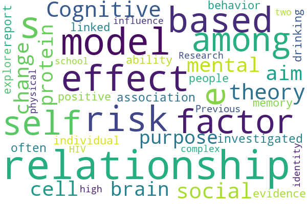

```python
# visualization

pyLDAvis.enable_notebook()
vis_1 = pyLDAvis.gensim.prepare(lda_model_X, corpus, dictionary)
vis_1
```

[interactive chart not shown]

Topic summaries

```python
lda_model = LatentDirichletAllocation(n_components=9, max_iter=10, learning_method='online', learning_offset=50.,random_state=0).fit(tfidf_title)
lda_W = lda_model.transform(tfidf_title)
lda_H = lda_model.components_

def display_topics(H, W, feature_names, title_list, no_top_words, no_top_documents):
    for topic_idx, topic in enumerate(H):
        print('\n',"Topic %d:" % (topic_idx))
        print("Top Words: "," ".join([feature_names[i] for i in topic.argsort()[:-no_top_words - 1:-1]]))
        top_doc_indices = np.argsort( W[:,topic_idx] )[::-1][0:no_top_documents]
        for doc_index in top_doc_indices:
            print(title_list[doc_index])

no_top_words = 15
no_top_documents = 4
title_list = copy['title'].tolist()
tf_feature_names = count_vectorizer.get_feature_names()
#display_topics(lda_H, lda_W, tf_feature_names, title_list, no_top_words, no_top_documents)

nmf_model = NMF(n_components=9, random_state=1, alpha=.1, l1_ratio=.5, init='nndsvd').fit(tfidf_title)
nmf_W = nmf_model.transform(tfidf_title)
nmf_H = nmf_model.components_

display_topics(nmf_H, nmf_W, tf_feature_names, title_list, no_top_words, no_top_documents)
```

```
 Topic 0:
Top Words:  the of and in to that for with we is on as this are study
Network Neuroscience and Personality.
Modeling motivational deficits in mouse models of schizophrenia: behavior analysis as a guide for neuroscience.
Pathways of influence in school-based mentoring: the mediating role of parent and teacher relationships.
Marginalized identities, discrimination burden, and mental health: empirical exploration of an interpersonal-level approach to modeling intersectionality.

 Topic 1:
Top Words:  hiv condom prep men msm use efficacy self sex peer among norms who disclosure stigma
Condom use peer norms and self-efficacy as mediators between community engagement and condom use among Chinese men who have sex with men.
Mediation Analysis of Peer Norms, Self-Efficacy, and Condom Use Among Chinese Men Who Have Sex with Men: A Parallel Process Latent Growth Curve Model.
Awareness and Acceptability of pre-exposure prophylaxis (PrEP) among gay, bisexual and other men who have sex with men (GBMSM) in Kenya.
Pre-exposure Prophylaxis Among Men Who have Sex with Men: Dual Motivational Model of Intention to Use Pre-exposure Prophylaxis.

 Topic 2:
Top Words:  use marijuana alcohol substance sensation and associations seeking examine gender young examined reasons substances school
Longitudinal trajectories of marijuana use from adolescence to young adulthood.
Pubertal status, sensation-seeking, impulsivity, and substance use in high school-aged boys and girls.
Reasons High School Students Use Marijuana: Prevalence and Correlations With Use Across Four Decades.
Characterization of substance use among underrepresented sexual and gender minority participants in The Population Research in Identity and Disparities for Equality (PRIDE) Study.

 Topic 3:
Top Words:  eating dissatisfaction disorder body symptoms hostility food binge addiction involvement anxiety alcohol dieting behaviors expectancies
Association between food addiction and body dissatisfaction among college students: The mediating role of eating expectancies.
Associations Between Alcohol Involvement and Drive for Thinness and Body Dissatisfaction in Adolescent Twins: A Bivariate Twin Study.
The moderating role of emotional reactivity in the link between parental hostility and eating disorder symptoms in early adolescence.
Evaluating the roles of anxiety and dimensions of perfectionism in dieting and binge eating using weekly diary methodology.

 Topic 4:
Top Words:  drinking alcohol motives negative consequences heavy related assault coping enhancement affect problem cope binge social
Effects of depressive symptoms and coping motives on naturalistic trends in negative and positive alcohol-related consequences.
Relationship of drinking motives with alcohol consumption and alcohol-related problems identified in a representative community-based study from Ningxia, China.
Social discomfort moderates the relationship between drinking in response to negative affect and solitary drinking in underage drinkers.
Do drinking motives mediate the association between sexual assault and problem drinking?

 Topic 5:
Top Words:  health mental rated self college relationship public men beijing leaders severity problems students ia internet
An Examination of Self-Rated Health Among African-American Men.
Five-factor personality traits and age trajectories of self-rated health: the role of question framing.
Declines in mental health associated with air pollution and temperature variability in China.
[Beijing college students' self-consciousness: its level, structure and relationship with mental health].

 Topic 6:
Top Words:  sexual minority women desire risk orientation minorities body discrimination rejection men hazardous dating dissatisfaction age
The relationships of sexual identity, hazardous drinking, and drinking expectancies with risky sexual behaviors in a community sample of lesbian and bisexual women.
Is Young Adulthood a Critical Period for Suicidal Behavior among Sexual Minorities? Results from a US National Sample.
Development and Validation of a Measure of Responsive Sexual Desire.
A Model of Female Sexual Desire: Internalized Working Models of Parent-Child Relationships and Sexual Body Self-Representations.

 Topic 7:
Top Words:  physical activity pa self adolescents apps concept factors active perceptions efficacy body regular dog sedentary
The Association Among Social Support, Self-Efficacy, Use of Mobile Apps, and Physical Activity: Structural Equation Models With Mediating Effects.
Exploring Path Models of Disablement in Residential Care and Assisted Living Residents.
The relationship between sport commitment and physical self-concept: Evidence for the self-enhancement hypothesis among adolescent females.
The relationship between transformational teaching and adolescent physical activity: the mediating roles of personal and relational efficacy beliefs.

 Topic 8:
Top Words:  bullying intervene willingness conflicts victimization perpetration students classroom social efficacy situations relationships student between in
Associations among Adolescents' Relationships with Parents, Peers, and Teachers, Self-Efficacy, and Willingness to Intervene in Bullying: A Social Cognitive Approach.
Students' Willingness to Intervene in Bullying: Direct and Indirect Associations with Classroom Cohesion and Self-Efficacy.
Bullying Perpetration and Victimization as Externalizing and Internalizing Pathways: A Retrospective Study Linking Parenting Styles and Self-Esteem to Depression, Alcohol Use, and Alcohol-Related Problems.
Future Expectations, Attitude Toward Violence, and Bullying Perpetration During Early Adolescence: A Mediation Evaluation.
```

Above topics were enriched.

### Quick stats

```python
publication_data = cleaned
```

```python
# Let's do a quick top 10s for the given lists

sns.set_style("white")
plt.figure(figsize=(10, 10), dpi=600)
```

```python
publication_data.columns
```

```
Index(['rank display', 'country code', 'country', 'size', 'focus', 'research',
       'age band', 'doi', 'year', 'number_authors', 'journal', 'title',
       'abstract', 'author', 'affiliation_y', 'latitude', 'longitude',
       'continent', 'fuzzy_matched_QS', 'original_affiliation',
       'Token_Set_Ratio'],
      dtype='object')
```

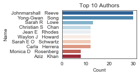

```python
# Top 10 authors
plt.subplot(2, 2, 1)

top10authors = pd.DataFrame.from_records(
    Counter(publication_data['author']).most_common(10), columns=["Name", "Count"]
)
sns.barplot(x="Count", y="Name", data=top10authors, palette="RdBu_r")
plt.title("Top 10 Authors")
```

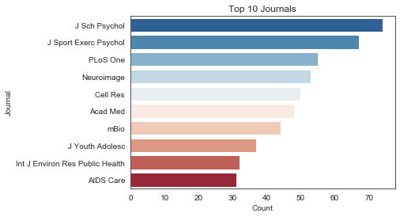

```python
# TOP 10 Journals
top10journals = pd.DataFrame.from_records(
    Counter(publication_data["journal"]).most_common(10),
    columns=["Journal", "Count"],
)
sns.barplot(x="Count", y="Journal", data=top10journals, palette="RdBu_r")
plt.title("Top 10 Journals")
```

```
(2010, 2020)
```

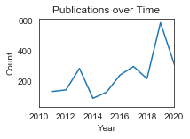

```python
# Publications over Time
plt.subplot(2, 2, 2)
yearly = pd.DataFrame(publication_data["year"].value_counts().reset_index())
yearly.columns = ["Year", "Count"]
sns.lineplot(x="Year", y="Count", data=yearly)
plt.title("Publications over Time")
plt.xlim([2010, 2020])
```

### Network analysis of authors

Which scientists publish together.

This segment is incomplete. I am still trying to understand how to access nodes from a networkx library. Neverthless, it is good for less than 100 authors. In our case there are over 600.

```python
# return a list of authors

split_author = lambda rank : [[str(y.strip()) for y in x.split('|')] for x in rank]

authors = split_author(copy["author"])

# flatten list function

def flatten_list(_2d_list):
    flat_list = []
    # Iterate through the outer list
    for element in _2d_list:
        if type(element) is list:
            # If the element is of type list, iterate through the sublist
            for item in element:
                flat_list.append(item)
        else:
            flat_list.append(element)
    return flat_list

# Extract author connections
author_connections = list(
    map(lambda x: list(combinations(x[::-1], 2)), authors)
)
flat_connections = flatten_list(author_connections)

# create a dataframe with conncetions
df_graph = pd.DataFrame.from_records(flat_connections, columns=["From", "To"])

df_graph = df_graph.groupby(["From", "To"]).size().reset_index()
df_graph.columns = ["From", "To", "Count"]
G = nx.from_pandas_edgelist(
    df_graph, source="From", target="To", edge_attr="Count"
)

# Limit to TOP 50 authors
#top50authors = pd.DataFrame.from_records(
#    Counter(flat_connections).most_common(50), columns=["Name", "Count"]
#)

#top50_nodes = (n for n in list(G.nodes()) if n in list(top50authors["Name"]))
#G_50 = G.subgraph(top50_nodes)
```

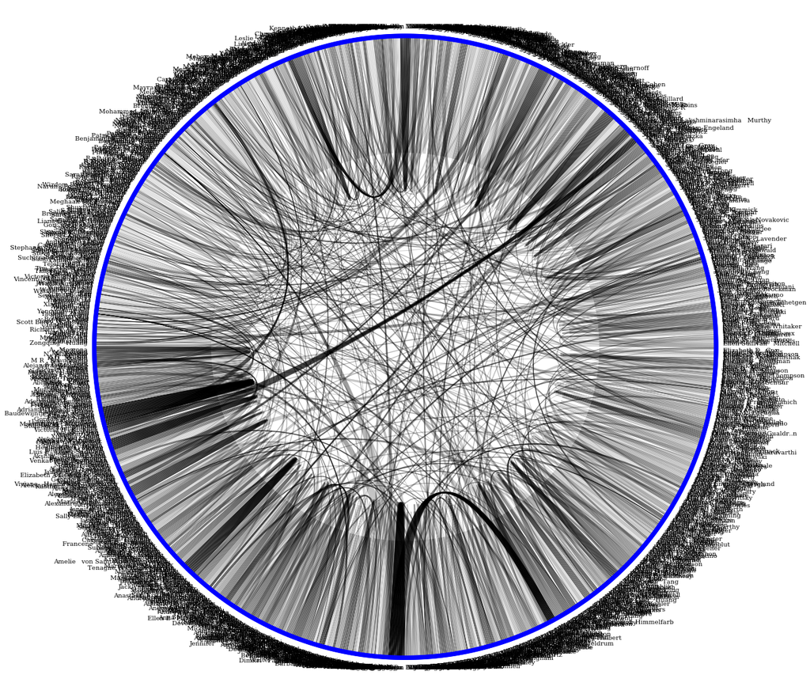

```python
c = CircosPlot(
    G,
    dpi=720,
    figsize=(20, 20),
    node_labels=True,
)
c.draw()
plt.show()
```

***